# Exploratory data analysis for geostatistical data

Sudipto Banerjee

2023-10-30

1. Begin by clearing memory.

```r
rm(list=ls())
```

2. Load required libraries. “MBA” is an R package for spatial interpolation using multilevel B-spline approximations. The package “fields” is an excellent package containing several functions for exploratory spatial data analysis for point-referenced data. It includes convenient functions for calculating distances between points using planar coordinates as well as great circle distances using spherical coordinates. The package “classInt” helps in creating classes and intervals for plotting category-based data. The package “geoR” offer functions for calculating variograms and carry out spatial model fitting and predictions.

```r
library(MBA)
library(fields)
library(classInt)
library(geoR)
```

3. Read the data set we will explore.

```r
data1=read.csv("../data/dataset1.csv")
```

4. Create a color palette.

```r
col.br <- colorRampPalette(c("midnightblue", "cyan", "yellow", "red"))
col.pal <- col.br(5)
```

5. Write a convenient function for plotting an interpolated surface of a column of a data table

```r
myplot=function(tab,colname){

  surf <- mba.surf(tab[,c("sx","sy",colname)], no.X=100, no.Y=100, h=5, m=2, extend=FALSE)$xyz.est
  image.plot(surf, xaxs = "r", yaxs = "r", xlab="Easting (m)", ylab="Northing (m)", col=col.br(25))

}
```

6. Apply the above function to plot surface maps for two variables “y” and “x” in our data.

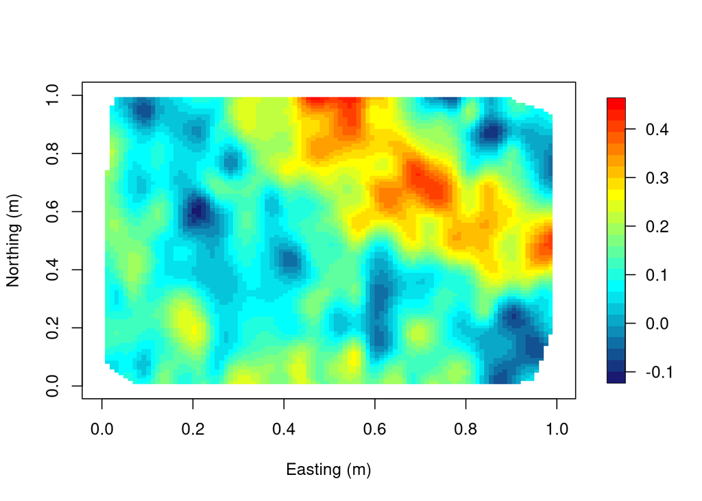

```r
myplot(data1,"y")
```

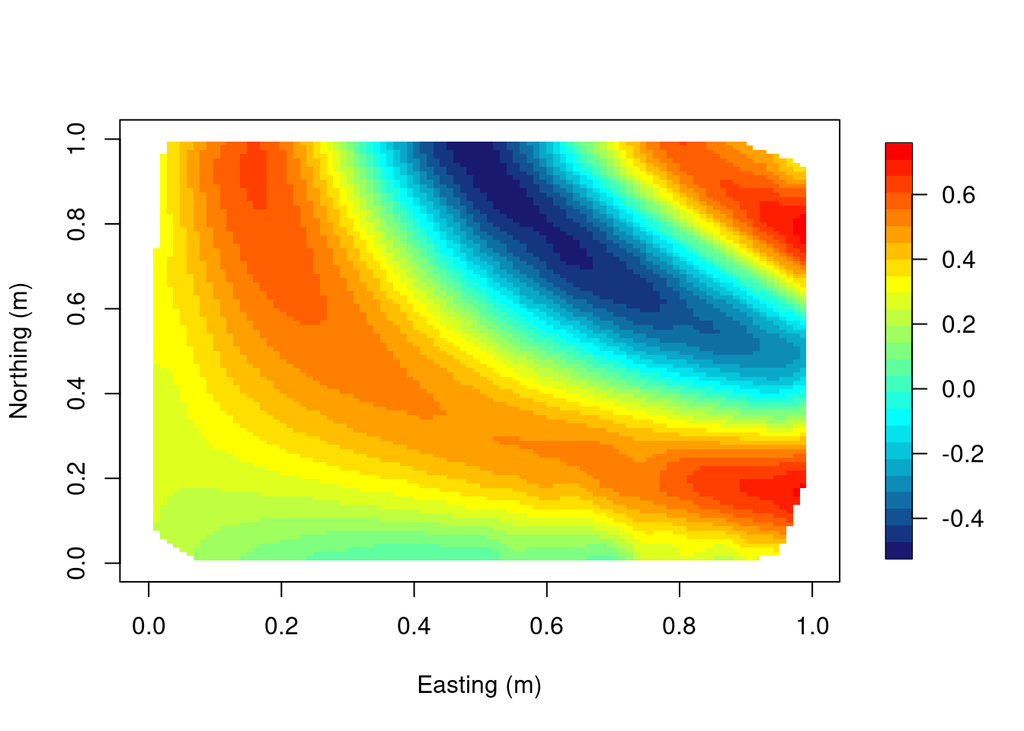

```r
myplot(data1,"x")
```

From the above two plots can you obtain a hint about how y and x are correlated? Let us confirm with a simple linear regression.

7. Fit a simple linear regression of y on x; obtain the residuals; plot a map of the residuals.

```r
lmobj1=lm(y~x,data=data1)
summary(lmobj1)
```

```
##
## Call:
## lm(formula = y ~ x, data = data1)
##
## Residuals:
##       Min        1Q    Median        3Q       Max
## -0.273066 -0.065792 -0.000407  0.064651  0.296026
##
## Coefficients:
##              Estimate Std. Error t value Pr(>|t|)
## (Intercept)  0.207767   0.005515   37.67   <2e-16 ***
## x           -0.306751   0.014207  -21.59   <2e-16 ***
## ---
## Signif. codes:  0 '***' 0.001 '**' 0.01 '*' 0.05 '.' 0.1 ' ' 1
##
## Residual standard error: 0.0999 on 498 degrees of freedom
## Multiple R-squared:  0.4835, Adjusted R-squared:  0.4825
## F-statistic: 466.2 on 1 and 498 DF,  p-value: < 2.2e-16
```

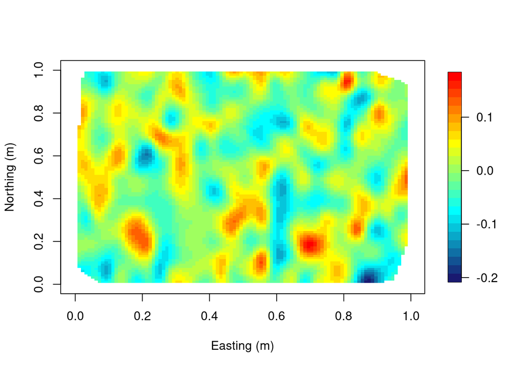

```r
data1$res=lmobj1$residuals
myplot(data1,"res")
```

8. Compute an empirical variogram of the dependent variable.

```r
max.dist <- 0.75*max(rdist(data1[,1:2]))
bins <- 20
vario1raw <- variog(coords=data1[,1:2], data=data1$y, uvec=(seq(0, max.dist, length=bins)))
```

```
## variog: computing omnidirectional variogram
```

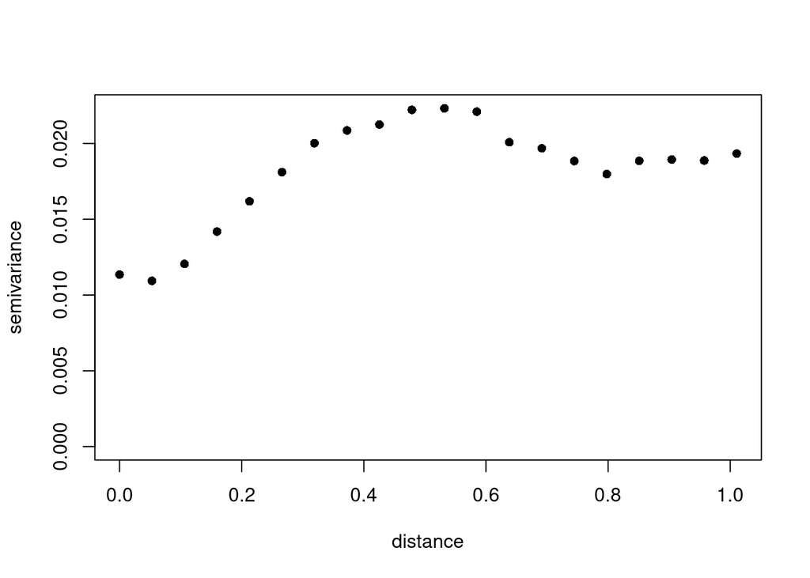

```r
plot(vario1raw,pch=16)
```

9. Compute an empirical variogram of the residuals.

```r
vario1 <- variog(coords=data1[,1:2], data=data1$res, uvec=(seq(0, max.dist, length=bins)))
```

```
## variog: computing omnidirectional variogram
```

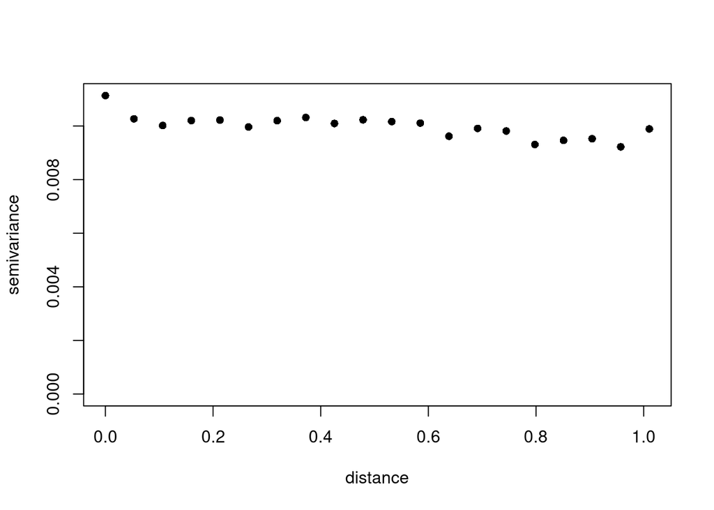

```r
plot(vario1,pch=16)
```

10. Read a new data set “Western Experimentaal Forest”.

```r
WEF.dat=read.csv("../data/WEFsmall.csv")
```

11. Hold out some data for predictions and for Root Mean Square Prediction Errors.

```r
set.seed(1) ## Set seed for reproducibility
ind=sample(1:nrow(WEF.dat),100,replace=FALSE) ##sample some rows for holdout
WEF.out=WEF.dat[ind,] ##Holdout or testing data
WEF.in=WEF.dat[-ind,] ##Input or training data
rm("WEF.dat") ##Remove the original data (optional) to free up memory
```

12. Extract some variables: diameter at breast height for the trees and their locations.

```r
DBH <- WEF.in$DBH_cm
coords <- as.matrix(WEF.in[,c("East_m","North_m")])
```

13. Create your color palette. Form intervals based on quantiles and plot the quantiles based on color coding of the locations.

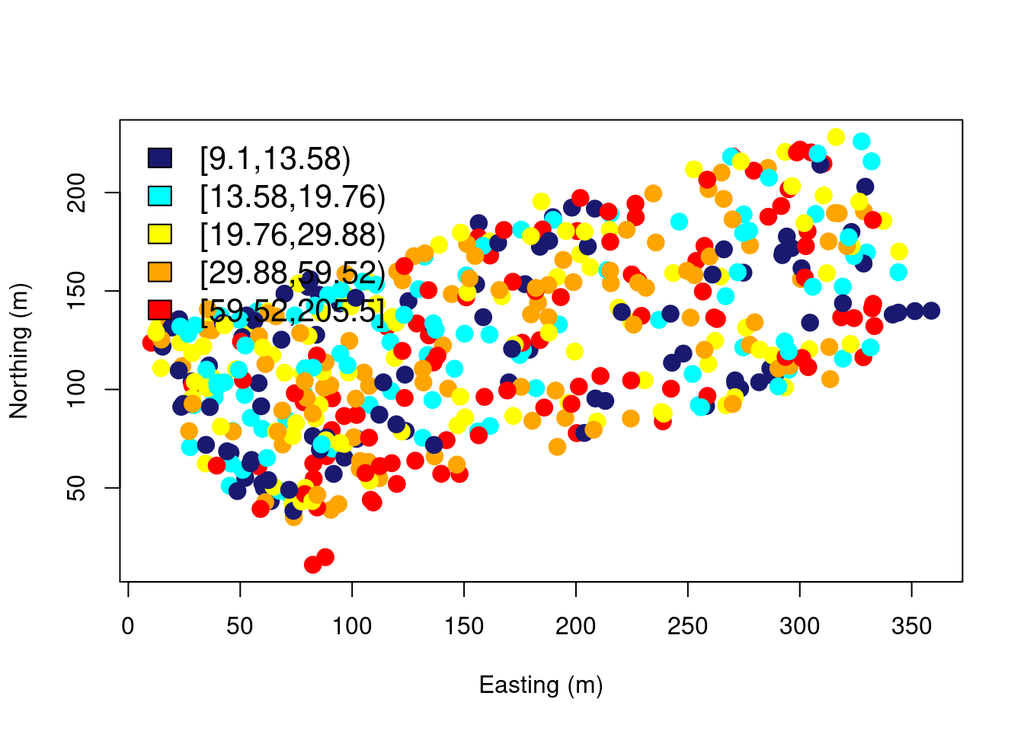

```r
col.br <- colorRampPalette(c("midnightblue", "cyan", "yellow",  "orange", "red"))
col.pal <- col.br(5)
quant <- classIntervals(DBH, n=5, style="quantile")
quant.col <- findColours(quant, col.pal)
plot(coords, col=quant.col, pch=19, cex=1.5, main="", xlab="Easting (m)", ylab="Northing (m)")
legend("topleft", fill=attr(quant.col, "palette"),
       legend=names(attr(quant.col, "table")), bty="n",cex=1.3)
```

14. Plot an interpolated surface using the MBA package.

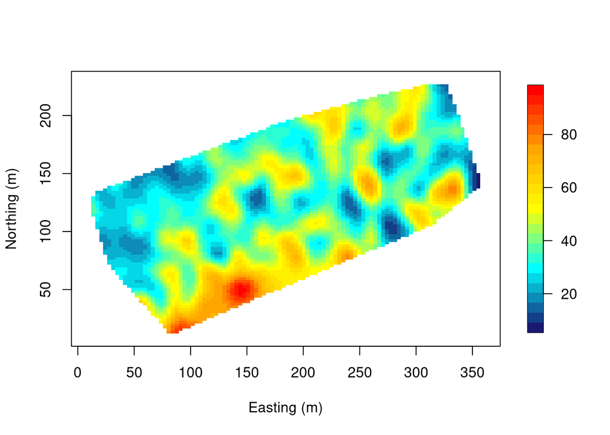

```r
surf <- mba.surf(cbind(coords,DBH), no.X=100, no.Y=100, h=5, m=2, extend=FALSE)$xyz.est
image.plot(surf, xaxs = "r", yaxs = "r", xlab="Easting (m)", ylab="Northing (m)", col=col.br(25))
```

15. Plot different species types. Use a new color palette to create color codes based on different species. Each species has its own color palette.

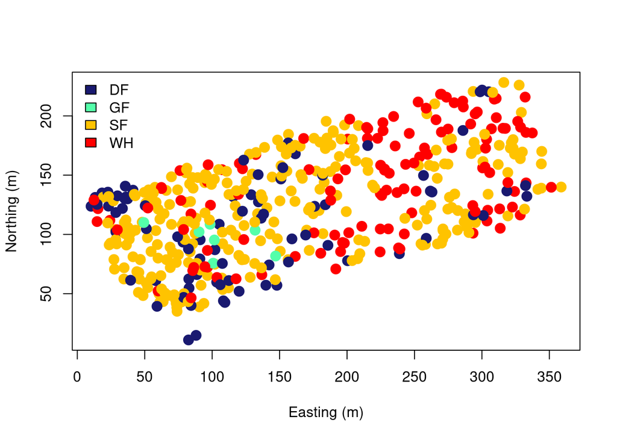

```r
spnum=as.factor(WEF.in$Species)
col.pal2 <- col.br(length(unique(spnum)))
plot(coords, col=col.pal2[spnum], pch=19, cex=1.5, main="", xlab="Easting (m)", ylab="Northing (m)")
legend("topleft", fill=col.pal2,
       legend=levels(spnum), bty="n")
```

16. Run a simple linear regressiion (ANOVA) on DBH against different species.

```r
lm.DBH <- lm(DBH~Species, data=WEF.in)
summary(lm.DBH)
```

```
##
## Call:
## lm(formula = DBH ~ Species, data = WEF.in)
##
## Residuals:
##     Min      1Q  Median      3Q     Max
## -77.870  -9.983  -3.065  10.131 116.630
##
## Coefficients:
##             Estimate Std. Error t value Pr(>|t|)
## (Intercept)   88.870      2.462  36.090  < 2e-16 ***
## SpeciesGF    -52.641      8.631  -6.099 2.15e-09 ***
## SpeciesSF    -67.804      2.780 -24.393  < 2e-16 ***
## SpeciesWH    -45.334      3.141 -14.433  < 2e-16 ***
## ---
## Signif. codes:  0 '***' 0.001 '**' 0.01 '*' 0.05 '.' 0.1 ' ' 1
##
## Residual standard error: 21.89 on 496 degrees of freedom
## Multiple R-squared:  0.5504, Adjusted R-squared:  0.5477
## F-statistic: 202.4 on 3 and 496 DF,  p-value: < 2.2e-16
```

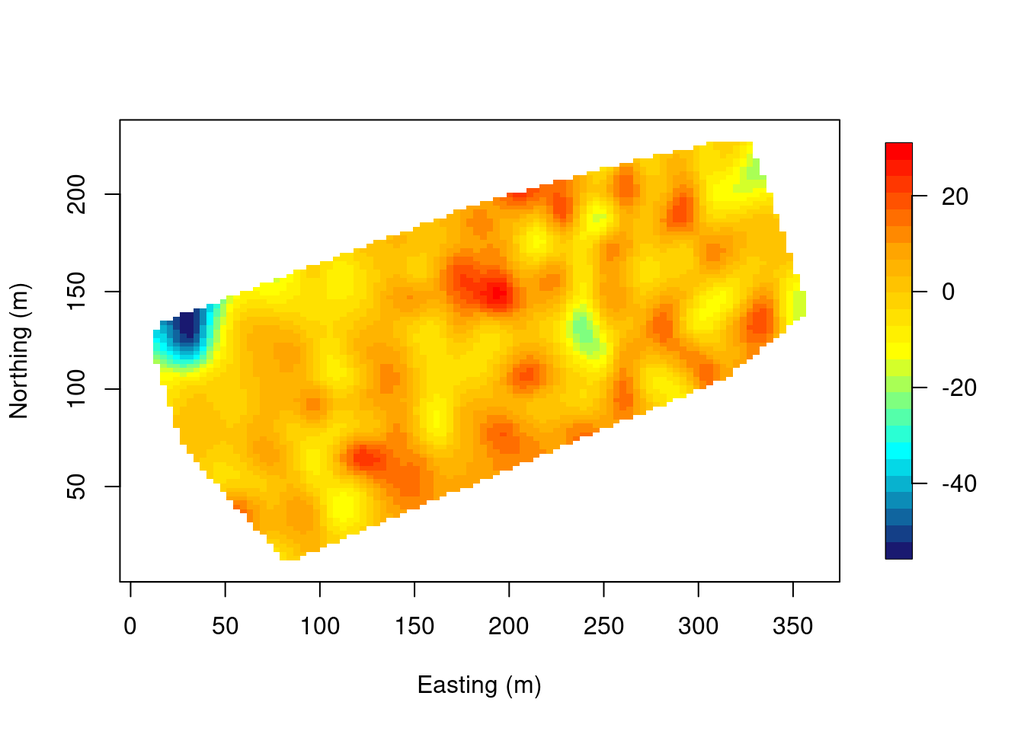

```r
DBH.resid <- resid(lm.DBH)
surf <- mba.surf(cbind(coords,DBH.resid), no.X=100, no.Y=100, h=5, m=2, extend=FALSE)$xyz.est
image.plot(surf, xaxs = "r", yaxs = "r", xlab="Easting (m)", ylab="Northing (m)", col=col.br(25))
```

18, Variogram of raw data and residuals

```r
max.dist=0.5*max(rdist(coords))
bins=20
vario.DBH <- variog(coords=coords, data=DBH, uvec=(seq(5, max.dist, length=bins)))
```

```
## variog: computing omnidirectional variogram
```

```r
vario.DBH.resid <- variog(coords=coords, data=DBH.resid, uvec=(seq(0, max.dist, length=bins)))
```

```
## variog: computing omnidirectional variogram
```

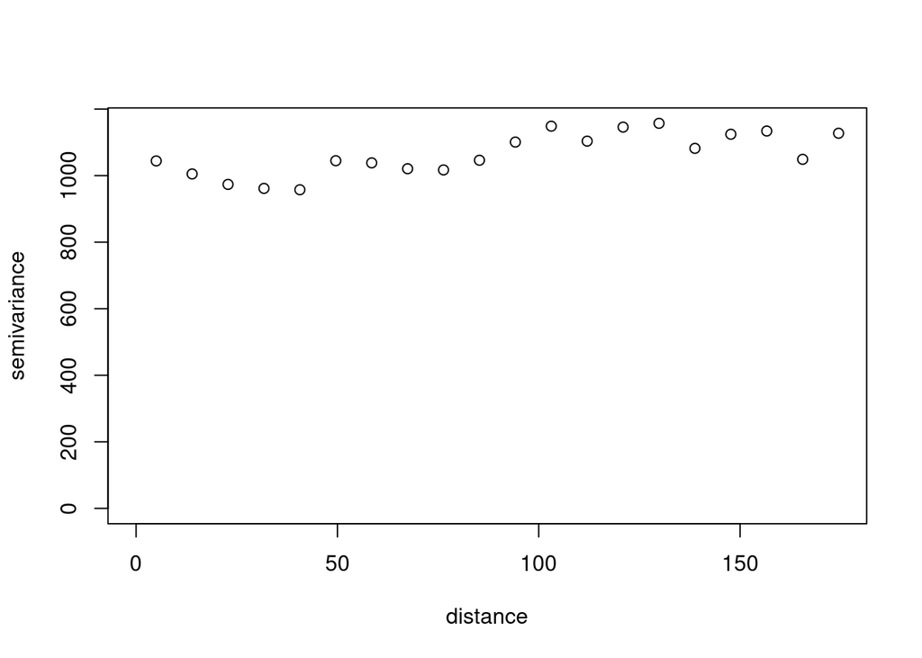

```r
plot(vario.DBH)
```

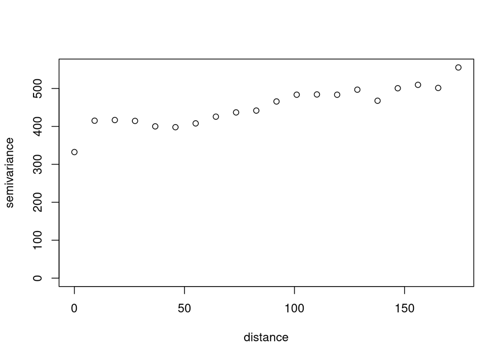

```r
plot(vario.DBH.resid)
```

19. Calculate the maximum likelihood estimates of model parameters. Also calculate two model comparison metrics AIC and BIC.

```r
mle <- likfit(coords=coords, data=DBH, trend = trend.spatial(~Species,WEF.in), ini.cov.pars=c(100,100),
              nugget = 300,cov.model="exponential",nospatial=TRUE)
```

```
## kappa not used for the exponential correlation function
## ---------------------------------------------------------------
## likfit: likelihood maximisation using the function optim.
## likfit: Use control() to pass additional
##          arguments for the maximisation function.
##         For further details see documentation for optim.
## likfit: It is highly advisable to run this function several
##         times with different initial values for the parameters.
## likfit: WARNING: This step can be time demanding!
## ---------------------------------------------------------------
## likfit: end of numerical maximisation.
```

```r
mle
```

```
## likfit: estimated model parameters:
##    beta0    beta1    beta2    beta3    tausq  sigmasq      phi
## " 89.53" "-57.83" "-72.19" "-50.72" "387.56" "128.09" " 79.48"
## Practical Range with cor=0.05 for asymptotic range: 238.1064
##
## likfit: maximised log-likelihood = -2227
```

```r
mle$AIC
```

```
## [1] 4467.843
```

```r
mle$BIC
```

```
## [1] 4497.345
```

20. Compare with nonspatial model.

```r
mle$nospatial$AIC
```

```
## [1] 4510.788
```

```r
mle$nospatial$BIC
```

```
## [1] 4531.861
```

21. Now calculate RMSPE from holdout locations.

```r
krig_mlefit=krige.conv(coords=coords, data=DBH,
    locations=WEF.out[,c("East_m","North_m")],krige=krige.control(type.krige="OK",obj.model=mle,
    trend.d=trend.spatial(~Species,WEF.in),trend.l=trend.spatial(~Species,WEF.out)))
```

```
## krige.conv: model with covariates matrix provided by the user
## krige.conv: Kriging performed using global neighbourhood
```

22. Calculate spatial predictions and RMSPE using holdout locations.

```r
pred_spatial=krig_mlefit$predict
rmspe_spatial=sqrt(mean((pred_spatial-WEF.out$DBH_cm)^2))

pred_lm=as.vector(as.matrix(trend.spatial(~Species,WEF.out))%*%lm.DBH$coefficients)
rmspe_lm=sqrt(mean((pred_lm-WEF.out$DBH_cm)^2))

rmspe_spatial
```

```
## [1] 18.77079
```

```r
rmspe_lm
```

```
## [1] 20.85809
```

23. Calculate prediction intervals, coverage probabilities (proportion of prediction intervals on holdout sets that include the value at that location) and the width of the confidence interval.

```r
CI_spatial=pred_spatial+1.96*sqrt(krig_mlefit$krige.var)%*%t(c(-1,1))  ## confidence interval ##
CP_spatial=mean(CI_spatial[,1]<WEF.out$DBH_cm & CI_spatial[,2]>WEF.out$DBH_cm) ## coverage probability ##
CIW_spatial=mean(CI_spatial[,2]-CI_spatial[,1]) ## confidence interval width ##

CP_spatial
```

```
## [1] 0.99
```

```r
CIW_spatial
```

```
## [1] 80.55797
```

24. Compare with predictions from simple linear model

```r
N=nrow(WEF.out)
CI_lm=pred_lm+1.96*summary(lm.DBH)$sigma*cbind(-rep(1,N),rep(1,N))
CP_lm=mean(CI_lm[,1]<WEF.out$DBH_cm & CI_lm[,2]>WEF.out$DBH_cm)
CIW_lm=mean(CI_lm[,2]-CI_lm[,1])

CP_lm
```

```
## [1] 0.94
```

```r
CIW_lm
```

```
## [1] 85.79468
```

25. Calculate a predicted surface.

```r
WEF.pred=read.csv("../data/WEFpred.csv")

krigsurf_mlefit=krige.conv(coords=coords, data=DBH,
    locations=WEF.pred[,c("East_m","North_m")],krige=krige.control(type.krige="OK",obj.model=mle,
    trend.d=trend.spatial(~Species,WEF.in),trend.l=trend.spatial(~Species,WEF.pred)))
```

```
## krige.conv: model with covariates matrix provided by the user
## krige.conv: Kriging performed using global neighbourhood
```

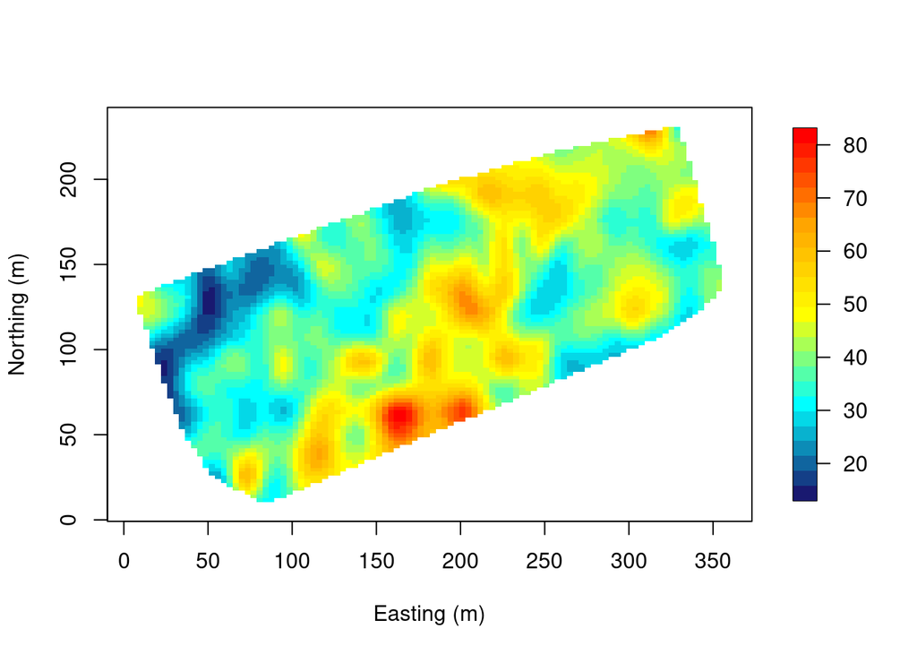

```r
pred=krigsurf_mlefit$predict
predsd=sqrt(krigsurf_mlefit$krige.var)

predsurf <- mba.surf(cbind(WEF.pred[,c("East_m","North_m")],pred), no.X=100, no.Y=100, h=5, m=2, extend=FALSE)$xyz.est
image.plot(predsurf, xaxs = "r", yaxs = "r", xlab="Easting (m)", ylab="Northing (m)", col=col.br(25))
```

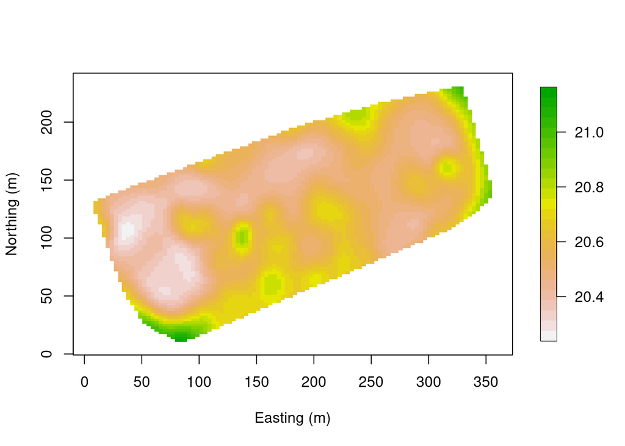

```r
predsdsurf <- mba.surf(cbind(WEF.pred[,c("East_m","North_m")],predsd), no.X=100, no.Y=100, h=5, m=2, extend=FALSE)$xyz.est
image.plot(predsdsurf, xaxs = "r", yaxs = "r", xlab="Easting (m)", ylab="Northing (m)", col=rev(terrain.colors(25)))
```